# Hw2: German Credit Data

## Task:

Analyze dataset “German Credit Data.” The objective is to predict whether the client’s credit is good or not (the binary variable V21).

```r
library(ggplot2)
```

## Task1

```
Q: Read the data description. Identify and report response variable and predictors.
```

```
* Response variable: V21
* Predictors: V1~V20
```

```r
#input data from url
data.url = 'http://www.yurulin.com/class/spring2018_datamining/data/german_credit_data.csv'
german = read.csv(file = data.url,head = TRUE, sep = ',')
```

## Task2

```r
#Explore the dataset, and generate both statistical and graphical summary with respect to the numerical and categorical variables. (Consider only the following variables in this exploration: V1, V2, V5, V7, V10, V11, V13, V15, V16, V19 and V21.)
```

### 2.(a)

```r
 #Qa) Generate a summary table for the data. For each numerical variable, list: variable name, mean, median, 1st quartile, 3rd quartile, and standard deviation.
```

```r
#apply summary table
numeric_values = c("V2","V5","V11","V13","V16")
summary_table = apply(german[,numeric_values],2,summary)
sd_table = apply(german[,numeric_values],2,sd)
result_table = rbind(summary_table,sd_table)#通过行bind列
result_table = t(round(result_table,2))#transform table
result_table
```

```
##     Min. 1st Qu. Median    Mean 3rd Qu.  Max. sd_table
## V2     4    12.0   18.0   20.90   24.00    72    12.06
## V5   250  1365.5 2319.5 3271.26 3972.25 18424  2822.74
## V11    1     2.0    3.0    2.85    4.00     4     1.10
## V13   19    27.0   33.0   35.55   42.00    75    11.38
## V16    1     1.0    1.0    1.41    2.00     4     0.58
```

### 2.(b)

```r
#For numerical variables, plot the density distribution. Describe whether the variable has a normal distribution or certain type of skew distribution.
```

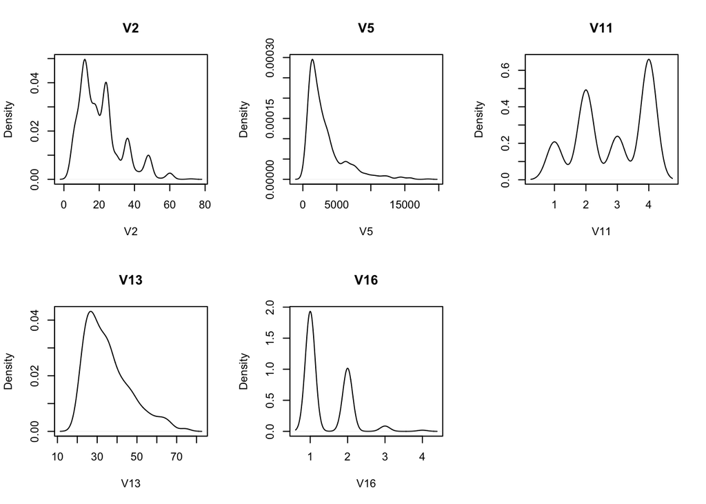

```r
par(mfrow=c(2,3))
for (numeric_value in numeric_values) {
  plot(density(german[,numeric_value]),xlab = numeric_value, main = numeric_value)
}
```

###Answer In summary:  
`V2` doesn’t have a normal distribution or a certain skew type;  
`V5` is skewed to the right;  
`V11` doesn’t have a normal distribution or a certain skew type; `V13` is skewed to right;  
`V16` doesn’t have a normal distribution or a certain skew type;

### 2.(c)

```r
#c) For each categorical predictor, generate the conditional histogram plot of response variable.
#hint: E.g., you can use facet_grid in ggplot.
```

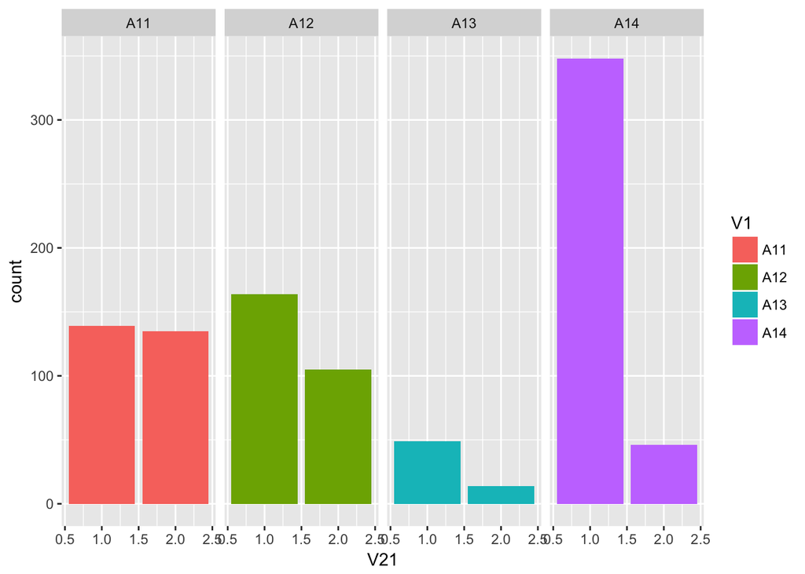

```r
par(mfrow=c(2,3))
cat_vals = c("V1","V7","V10","V15","V19","V21")
ggplot(german,aes(x = V21,fill = V1)) + geom_bar(stat = "count") +facet_grid(.~V1)
```

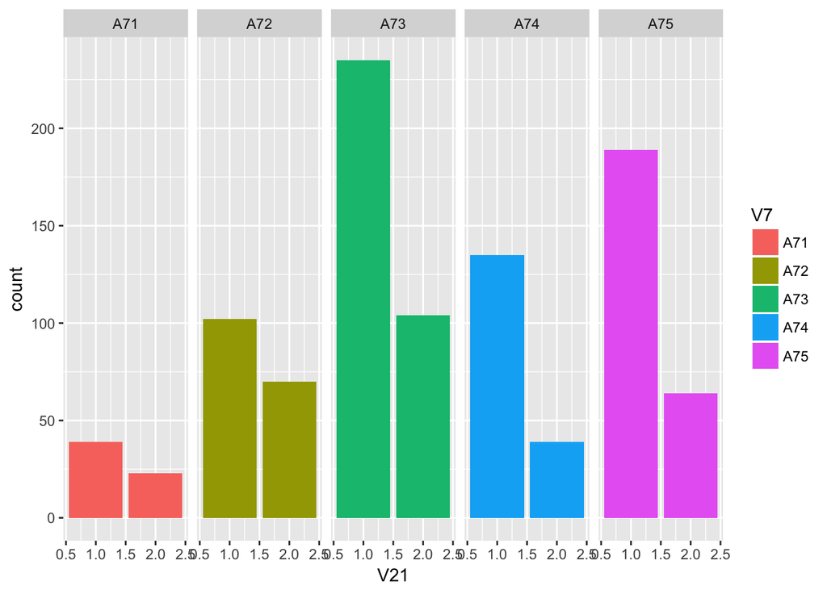

```r
ggplot(german,aes(x = V21,fill = V7)) + geom_bar(stat = "count") +facet_grid(.~V7)
```

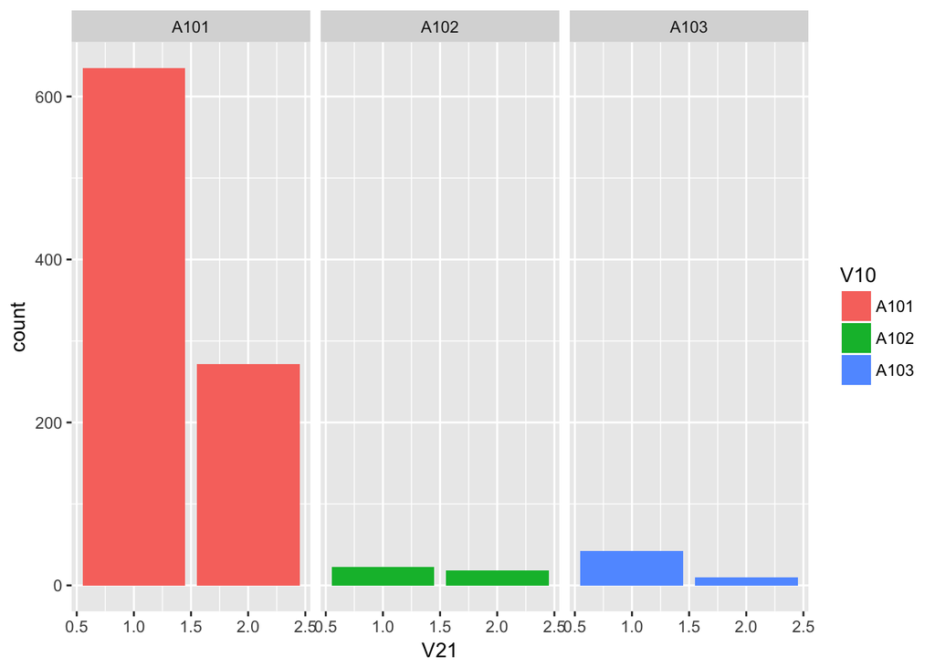

```r
ggplot(german,aes(x = V21,fill = V10)) + geom_bar(stat = "count") +facet_grid(.~V10)
```

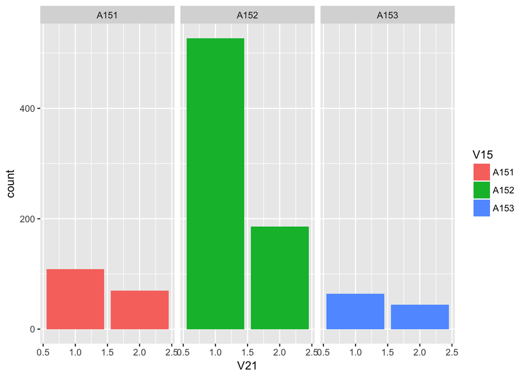

```r
ggplot(german,aes(x = V21,fill = V15)) + geom_bar(stat = "count") +facet_grid(.~V15)
```

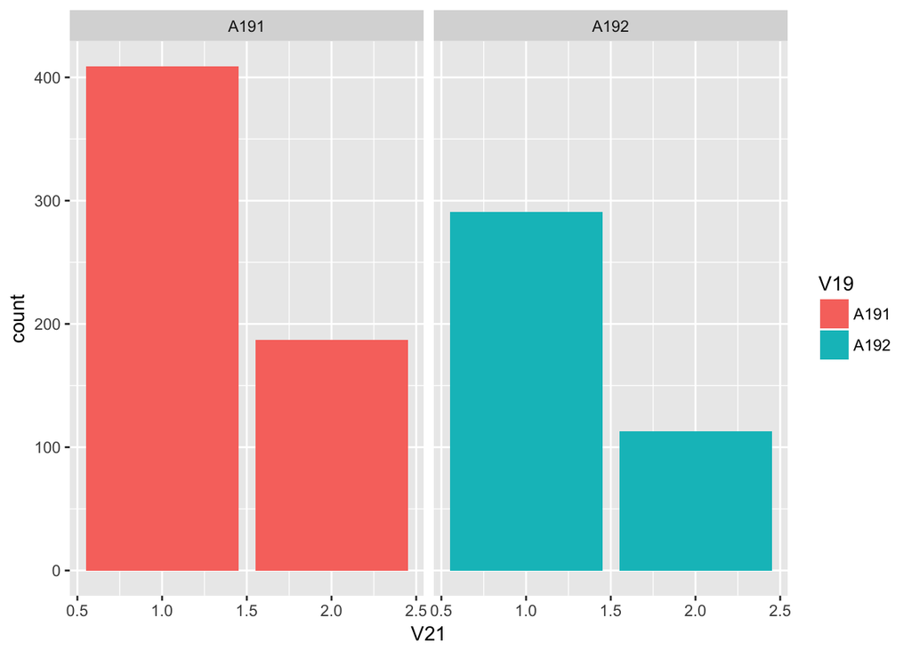

```r
ggplot(german,aes(x = V21,fill = V19)) + geom_bar(stat = "count") +facet_grid(.~V19)
```

## Task3

```r
#Apply logistic regression analysis to predict V21. Evaluate the models through cross-validation and on holdout samples. Interpret the effect of the predictors.
```

### 3.(a)

```r
#Implement a 10-fold cross-validation scheme by splitting the data into training and testing sets. Use the training set to train a logistic regression model to predict the response variable. Examine the performance of different models by varing the number of predictors. Report the performance of the models on testing set using proper measures (accuracy, precision, recall, F1) and plots (ROC, lift).
```

## Data Clean

```r
library(car)
suppressMessages( library(textir) )
#recode V21 = 2 to 0
german$V21 = recode(german$V21,"1=1;else=0")
#recode qualitive value
numerical_col = c(2,5,8,11,13,16,18)
data_numerical = german[,numerical_col]
data_qualitive = german[,-numerical_col]

#recode qualitive value
data_transform = model.matrix(V21~.,data=data_qualitive)[,-1]
#normalize numerical value
#data_normalize = scale(data_numerical[,])
german_new <- cbind(data_numerical,data_transform)
```

```r
#ROC
library(ROCR)
library(pROC)
```

```r
Curve.Roc<- function(ptest,ytest){
  ## ROC for hold-out period
  data = data.frame(predictions=ptest,labels=ytest)
  ## pred: function to create prediction objects
  pred <- prediction(data$predictions,data$labels)
  ## perf: creates the input to be plotted
  ## sensitivity (TPR) and one minus specificity (FPR)
  perf <- performance(pred, "sens", "fpr")
  plot(perf)
  area <- auc(data$labels,data$predictions)
  area <- format(round(area, 4), nsmall = 4)
  text(x=0.8, y=0.1, labels = paste("AUC =", area))
  segments(x0=0, y0=0, x1=1, y1=1, col="gray", lty=2)
}
```

```r
#Lift
Curve.Lift<-function(ptest,ytest){
  df=cbind(ptest,ytest)
  rank.df=as.data.frame(df[order(ptest,decreasing=TRUE),])
  colnames(rank.df) = c('predicted','actual')
  baserate=mean(ytest)
  ## calculating the lift
  ## cumulative 1's sorted by predicted values
  ## cumulative 1's using the average success prob from evaluation set
  n.test = 100
  ax=dim(n.test)
  ay.base=dim(n.test)
  ay.pred=dim(n.test)
  ax[1]=1
  ay.base[1]=baserate
  ay.pred[1]=rank.df$actual[1]
  for (i in 2:n.test) {
    ax[i]=i
    ay.base[i]=baserate*i ## uniformly increase with rate xbar
    ay.pred[i]=ay.pred[i-1]+rank.df$actual[i]
  }

  df=cbind(rank.df,ay.pred,ay.base)
  plot(ax,ay.pred,xlab="number of cases",ylab="number of successes",main="Lift: Cum successes sorted by pred val/success prob")
  points(ax,ay.base,type="l")
}
```

```r
my_model<-function(proportion){
  set.seed(88)
  fold_length = nrow(german)/10
  precision = 0
  accuracy = 0
  recall = 0
  F1 = 0
  best_recall = 0
  best_vary = c()
  best_precision = 0
  best_accuracy = 0
  best_F1 = 0
  best_feature = c()
  german_new = data.frame(german_new)
  #define the proportion of predictors taken into training
  for(i in c(rep(proportion,5))){
    #define feature for training
    feature = sample(1:length(german_new),floor(length(german_new) * i))
    accuracy = 0
    precision = 0
    recall = 0
    F1 = 0
    #kfold
    for(j in 1: 10){
      #define data row for training
      #set 900 for train and validate, 901-1000 for test
      start_pos = 90*(j -1) + 1
      end_pos = 90*j
      data_sample = start_pos:end_pos
      #split training and test data
      xtrain = german_new[-data_sample,feature]
      ytrain = german$V21[-data_sample]
      xtest = german_new[data_sample,feature]
      ytest = german$V21[data_sample]
      #fit the logisitc model
      ml = glm(V21~.,family=binomial,data=data.frame(V21=ytrain,xtrain))
      #predict
      ptest = predict(ml,newdata=data.frame(xtest),type="response")
      #use floor function to clamp the value to 0 or 1
      btest=floor(ptest+0.5)
      #get confusion matrix
      conf.matrix = table(ytest,btest)
      #get precision
      precision = precision + conf.matrix[2,2] / (conf.matrix[2,2]+conf.matrix[1,2])
      #get accuracy
      accuracy = accuracy + (conf.matrix[1,1] + conf.matrix[2,2]) / 100
      #get recall
      recall = recall + conf.matrix[2,2] / (conf.matrix[2,2]+conf.matrix[2,1])
      #get F1
      F1 = F1 + 2 * precision * recall / (precision + recall)
    }
      if(recall/10 > best_recall){
        best_feature = feature
        best_conf.matrix = conf.matrix
        best_recall = recall/10
        best_vary = i
        best_precision = precision/10
        best_F1 = F1/10
        best_accuracy = accuracy/10
      }

  }
  best_model = glm(V21~.,family=binomial,data=data.frame(V21=german$V21,german_new[,sort(best_feature)]))
  #set 901 - 1000 for test
  ptest = predict(best_model,newdata=data.frame(german_new[901:1000,]),type="response")
  Curve.Lift(ptest,german$V21[901:1000])
  Curve.Roc(ptest,german$V21[901:1000])
  print(best_conf.matrix)
  print(rbind(best_recall,best_precision,best_F1,best_accuracy))
  return(best_feature)
}
```

## First Model use All predictors

```r
feature.1 = my_model(1)
```

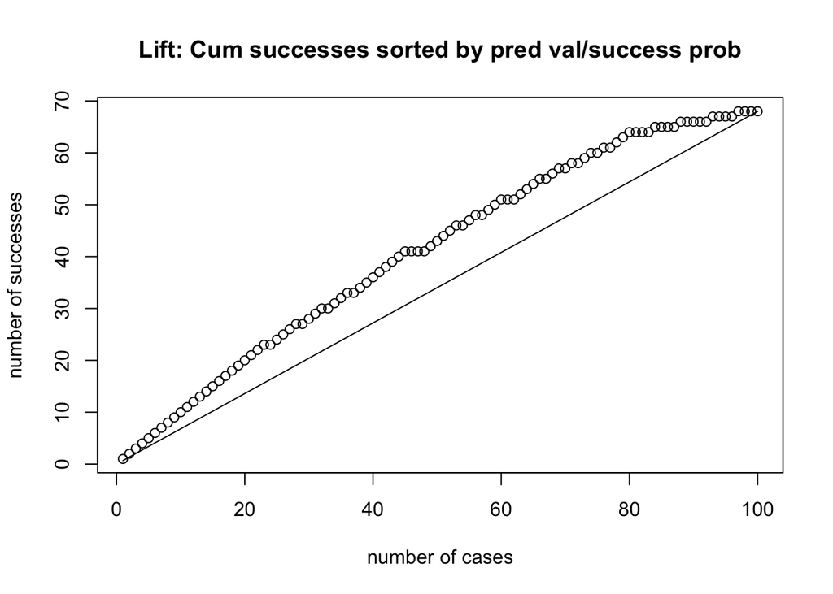

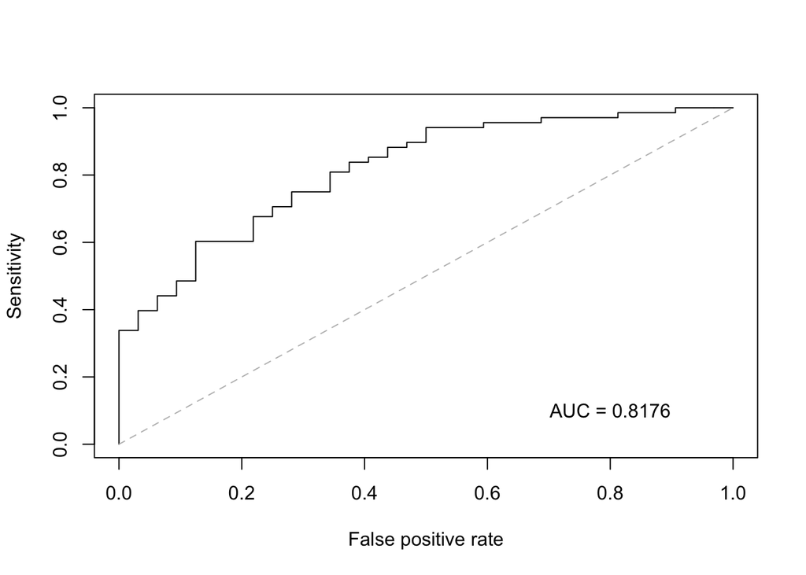

```
##      btest
## ytest  0  1
##     0 15 12
##     1 10 53
##                     [,1]
## best_recall    0.8689285
## best_precision 0.8003240
## best_F1        4.6085770
## best_accuracy  0.6790000
```

## Second Model use 90% predictors

```r
feature.9 = my_model(0.9)
```

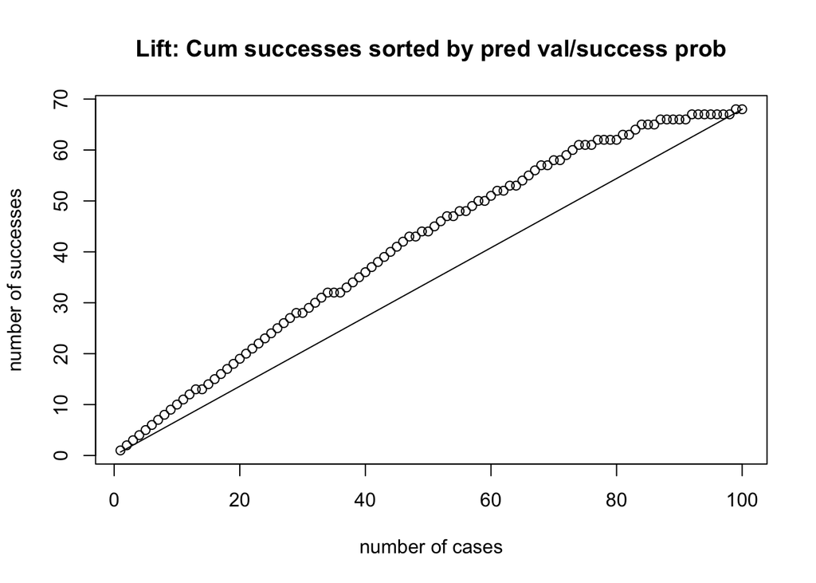

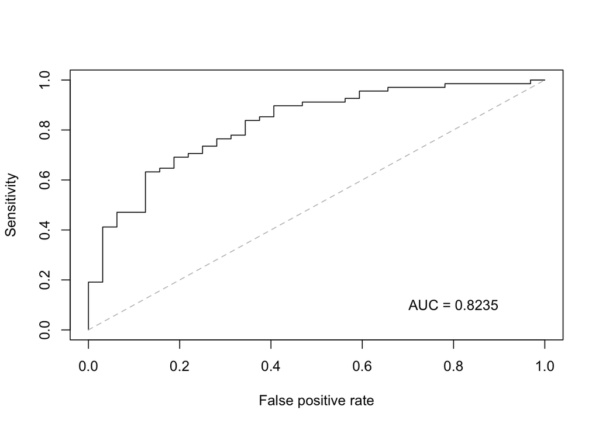

```
##      btest
## ytest  0  1
##     0 13 14
##     1  8 55
##                     [,1]
## best_recall    0.8699310
## best_precision 0.7924344
## best_F1        4.5985328
## best_accuracy  0.6740000
```

## Third Model use 80% predictors

```r
feature.8 = my_model(0.8)
```

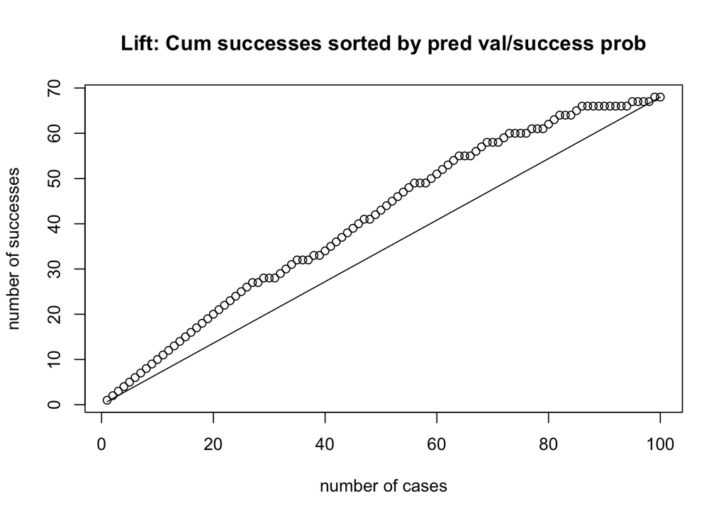

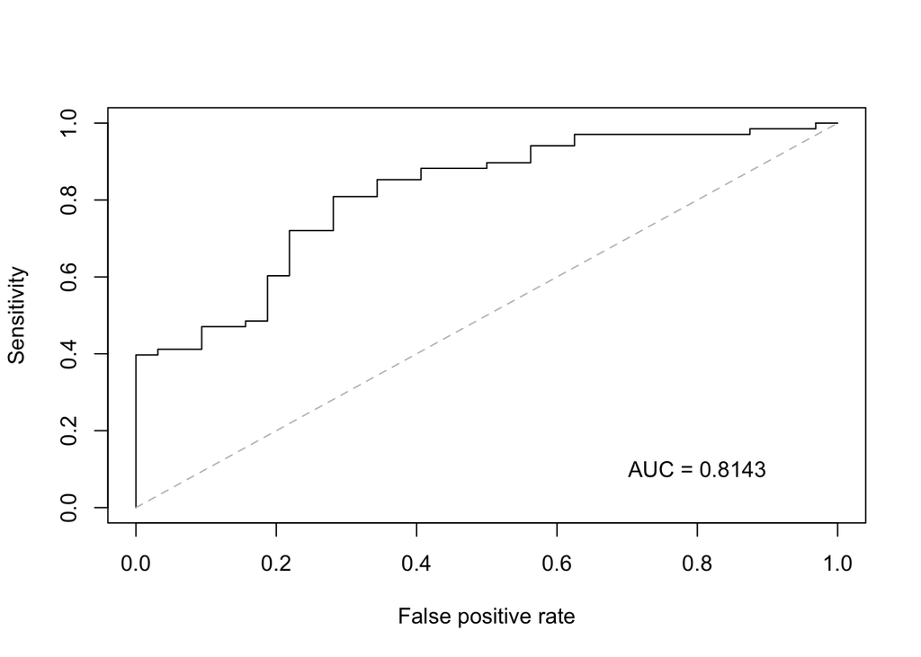

```
##      btest
## ytest  0  1
##     0 11 16
##     1  7 56
##                     [,1]
## best_recall    0.8816480
## best_precision 0.7800892
## best_F1        4.5946046
## best_accuracy  0.6690000
```

## 4th Model use 70% predictors

```r
feature.7 = my_model(0.7)
```

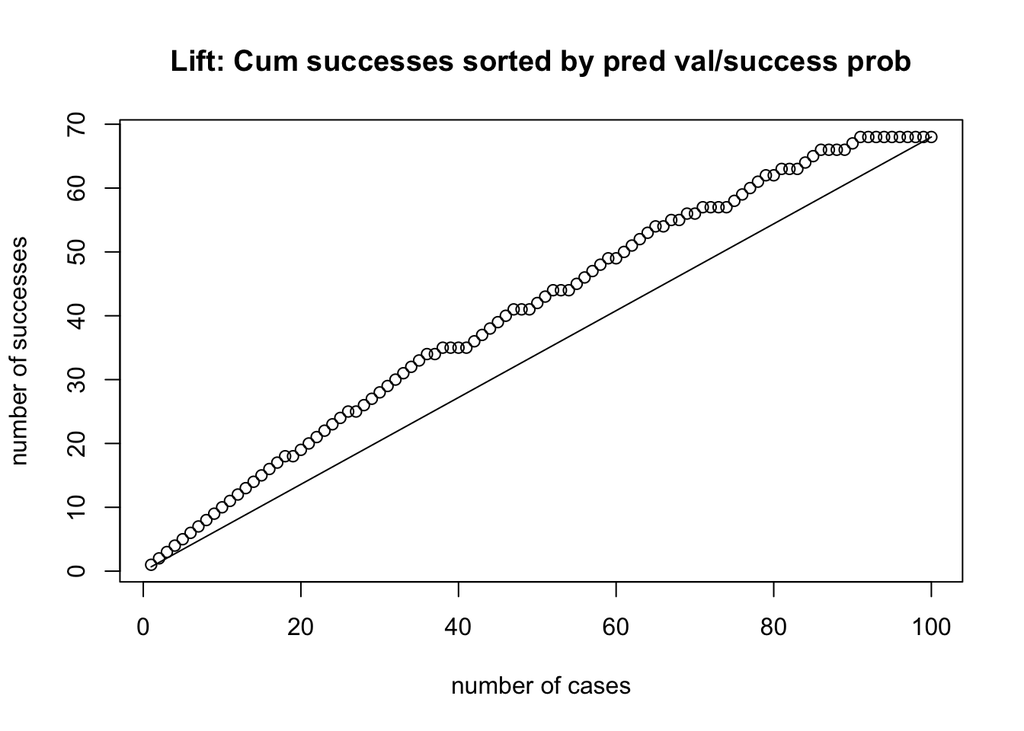

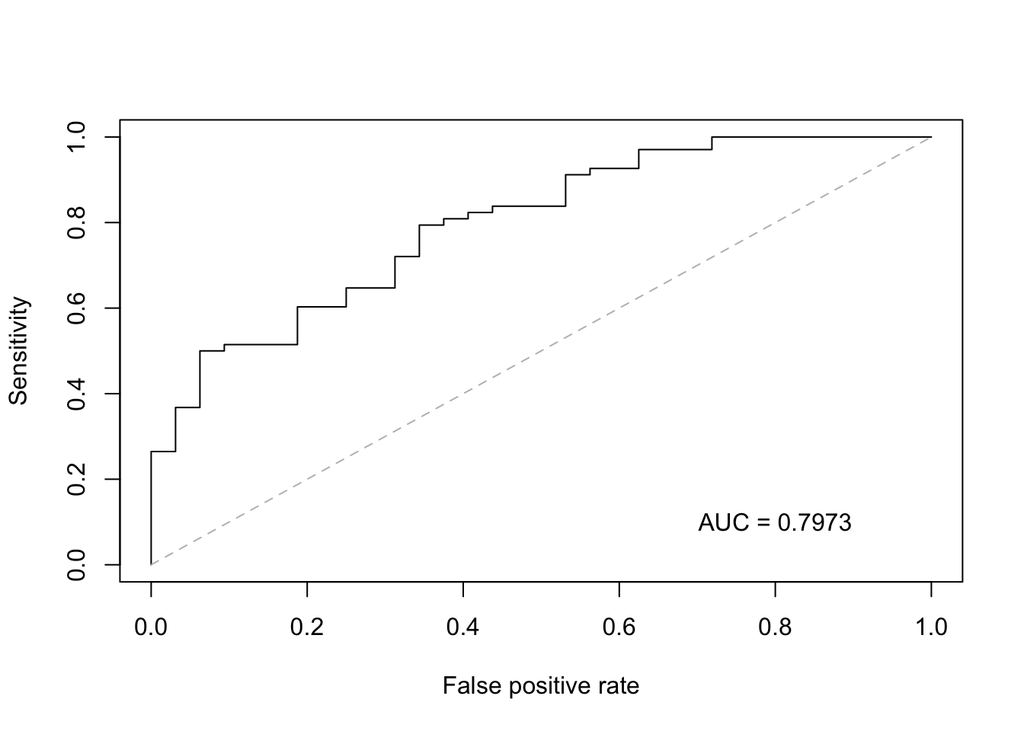

```
##      btest
## ytest  0  1
##     0  5 22
##     1  5 58
##                     [,1]
## best_recall    0.9174862
## best_precision 0.7544041
## best_F1        4.5932072
## best_accuracy  0.6580000
```

```r
#compute the odds ratio and interpret the effect of each predictors.
```

### Answer

As the data description said “It is worse to class a customer as good when they are bad, than it is to class a customer as bad when they are good”. So I think the best model should focus on both of FPR and TPR, so I use AUC to decide best Model.  
So the best model is 90% feature model.

```r
best_model = glm(V21~.,family=binomial,data=data.frame(V21=german$V21,german_new[,sort(feature.9)]))
summary(best_model)
```

```
##
## Call:
## glm(formula = V21 ~ ., family = binomial, data = data.frame(V21 = german$V21,
##     german_new[, sort(feature.9)]))
##
## Deviance Residuals:
##     Min       1Q   Median       3Q      Max
## -2.7416  -0.7433   0.3777   0.7167   2.3391
##
## Coefficients:
##               Estimate Std. Error z value Pr(>|z|)
## (Intercept) -1.696e-02  9.417e-01  -0.018 0.985631
## V2          -2.882e-02  9.185e-03  -3.138 0.001701 **
## V5          -1.270e-04  4.446e-05  -2.856 0.004290 **
## V8          -3.309e-01  8.702e-02  -3.802 0.000143 ***
## V11         -4.122e-04  8.468e-02  -0.005 0.996116
## V18         -3.134e-01  2.450e-01  -1.279 0.200857
## V1A13        8.235e-01  3.517e-01   2.341 0.019216 *
## V1A14        1.575e+00  2.011e-01   7.834 4.73e-15 ***
## V3A31        6.126e-02  5.240e-01   0.117 0.906934
## V3A32        6.784e-01  4.102e-01   1.654 0.098185 .
## V3A33        8.722e-01  4.675e-01   1.866 0.062092 .
## V3A34        1.336e+00  4.319e-01   3.092 0.001986 **
## V4A41        1.614e+00  3.704e-01   4.358 1.31e-05 ***
## V4A410       1.488e+00  7.829e-01   1.900 0.057381 .
## V4A42        7.011e-01  2.557e-01   2.742 0.006099 **
## V4A43        8.562e-01  2.414e-01   3.547 0.000390 ***
## V4A44        4.462e-01  7.459e-01   0.598 0.549725
## V4A45        1.869e-01  5.463e-01   0.342 0.732197
## V4A46       -6.417e-02  3.910e-01  -0.164 0.869641
## V4A49        7.118e-01  3.293e-01   2.161 0.030662 *
## V6A62        3.599e-01  2.777e-01   1.296 0.195024
## V6A64        1.396e+00  5.228e-01   2.671 0.007566 **
## V6A65        9.708e-01  2.565e-01   3.785 0.000154 ***
## V7A72       -5.529e-03  4.186e-01  -0.013 0.989461
## V7A73        1.241e-01  4.038e-01   0.307 0.758610
## V7A74        7.639e-01  4.370e-01   1.748 0.080426 .
## V7A75        3.088e-01  4.084e-01   0.756 0.449591
## V9A92        2.134e-01  3.785e-01   0.564 0.572895
## V9A93        7.611e-01  3.734e-01   2.038 0.041517 *
```

[output cut: 10 more lines]

```
## V17A172     -4.624e-01  6.657e-01  -0.695 0.487256
## V17A173     -5.788e-01  6.426e-01  -0.901 0.367748
## V17A174     -4.577e-01  6.490e-01  -0.705 0.480666
## V19A192      3.173e-01  1.973e-01   1.608 0.107826
## V20A202      1.307e+00  6.255e-01   2.090 0.036662 *
## ---
## Signif. codes:  0 '***' 0.001 '**' 0.01 '*' 0.05 '.' 0.1 ' ' 1
##
## (Dispersion parameter for binomial family taken to be 1)
##
##     Null deviance: 1221.73  on 999  degrees of freedom
## Residual deviance:  908.89  on 956  degrees of freedom
## AIC: 996.89
##
## Number of Fisher Scoring iterations: 5
```

Effect of Predictors: For each predictor, lower P value means it is more important to the model.

```r
#For the best model, compute the odds ratio and interpret the effect of each predictors.
exp(best_model$coefficients)
```

```
## (Intercept)          V2          V5          V8         V11         V18
##   0.9831840   0.9715905   0.9998730   0.7182892   0.9995879   0.7309310
##       V1A13       V1A14       V3A31       V3A32       V3A33       V3A34
##   2.2784949   4.8317139   1.0631715   1.9706878   2.3922546   3.8019777
##       V4A41      V4A410       V4A42       V4A43       V4A44       V4A45
##   5.0245102   4.4275597   2.0160225   2.3540825   1.5623239   1.2055542
##       V4A46       V4A49       V6A62       V6A64       V6A65       V7A72
##   0.9378457   2.0377108   1.4331961   4.0398388   2.6401118   0.9944867
##       V7A73       V7A74       V7A75       V9A92       V9A93       V9A94
##   1.1321143   2.1466915   1.3617344   1.2378942   2.1406425   1.4678351
##     V10A102     V10A103     V12A122     V12A123     V12A124     V14A142
##   0.6029193   2.6114143   0.7554343   0.8220623   0.5132593   1.0708190
##     V14A143     V15A152     V15A153     V17A172     V17A173     V17A174
##   1.9312242   1.6797318   2.1759596   0.6297412   0.5605716   0.6327502
##     V19A192     V20A202
##   1.3734331   3.6948009
```